# Filtr Kalman

Doynikov A

April 21, 2021

# Пространственно временные модели состояний. Фильтр Калмана

Эффективная и очень популярная в приложениях модель, оценивающая вектор состояний динамической системы, используя ряд неполных и зашумленных измерений была предлдожена Рудольфом Калманом в 1960 году. Модель получила название фильтр Кальмана.Фильтр Калмана — это, наверное, самый популярный алгоритм фильтрации, используемый во многих областях науки и техники. Благодаря своей простоте и эффективности его можно встретить в GPS-приемниках, обработчиках показаний датчиков, при реализации систем управления в системах автопилота, управления движения подводных лодок, в финансовой сфере и т.д. Пусть $y_t$ - n-мерный вектор наблюдаемый в момент t. Пусть динамика модели описывается r-мерным вектором $\xi_t$ (возможно не наблюдаемый), который носит название вектора состояний (state vector). Пусть динамика процесса $y_t$ описывается следующей систмой уравнений:
$$\xi_{t+1}=F\xi_t+v_t$$
$$y_t=A'x_t+H'\xi_t+w_t$$
где $F,A',H'$ матрицы параметров модели размера #(rr),(nk), (nr)$ соответственно, $x_t$- k-мерный вектор экзогенненных (предопределенных) переменных. Первое из уравнений носит название “уравнение состояний”(State equation),второе “уравнение наблюдений”, а про вектора $w_t,v_t$известно, что их ковариационные матрицы $Q,R$ соответственно и для любых моментов времени $t,\tau$
$$cov(v_t,w'_{\tau})= 0$$
Системы уравнений обычно используются для описания конечного числа наблюдений $y_1,...,t_T$ для которых начальное значение вектора состояний $\xi_1$ задано. Также будем предполагать, что
$$E(v_t,\xi_1)=0; t = 1,2,...,T$$
,
$$E(w_t,\xi_1)=0; t = 1,2,...,T (*)$$

Из первого уравнения системы следует, что
$$\xi_t=v_t+Fv_t{-1}+F^2v_{t-2}+...+F^{t-2}v_{2}+F^{t-1}\xi_1$$
$$t=2,3,...,T$$
Из прдположений (*) следует, что
$$E(v_t,\xi'_{\tau})=0; \tau = t-1,t-2,...,1$$
Аналогично из предположений модели немедленно получаем:
$$E(w_t,\xi'_{\tau})= 0; \tau = 1,2,...,T$$
$$E(w_t,y'_{\tau})= E(w_t,(A'x_{\tau}+H'\xi_{\tau}+w_t)')=0; \tau = t-1,t-2,...,1$$
$$E(v_t,y'_{\tau})= 0; \tau = t-1,t-2,...,1$$
Для примера рассмотрим одномерный AR(p) процесс.
Пусть
$$y_{t+1}-\mu= \phi_1(y_{t}-\mu)+...\phi_p (y_{t-p+1}-\mu)+\epsilon_t$$
Тогда это можно переписать в рамках рассматриваемой модели.

### Уравнение состяний будет:

$\begin{equation*} \left[ \begin{matrix} y_{t+1}-\mu \\ y_{t}-\mu\\ ....\\....\\ y_{t-p+2}-\mu\end{matrix} \right] =\left[ \begin{matrix}\phi_1&\phi_2&....&\phi_p\\ 1&0& ...&0\\0&1&...&0\\.....\\0&...&1&0 \end{matrix} \right]\left[ \begin{matrix}y_{t}-\mu\\y_{t-1}-\mu\\....\\y_{t-p+1}-\mu \end{matrix} \right] \end{equation*}$

### Уравнение наблюдений

$$\begin{equation*} y_t=\mu+\left[ \begin{matrix} 1&0&0&...&0\end{matrix} \right] \left[ \begin{matrix} y_t-\mu\\y_{t-1}-\mu\\...\\y_{t-p+1}-\mu \end{matrix} \right]\end{equation*}$$
Итак
$$\begin{equation*} \xi_t=\left[ \begin{matrix}y_t-\mu\\y_{t-1}-\mu\\...\\
y_{t-p+1}-\mu\end{matrix} \right]\end{equation*}$$
$$\begin{equation*}F=\left[ \begin{matrix}\phi_1&\phi_2&...&\phi_p \\1&0&...&0\\0&1&...&0\\0&...&1&0\end{matrix} \right]\end{equation*}$$
$$\begin{equation*}v_{t+1}=\left[ \begin{matrix}\epsilon_{t+1}\\0\\..\\0\end{matrix} \right]\end{equation*}$$
$$\begin{equation*}Q=\left[ \begin{matrix}\sigma^2&0&...&0\\0&0&..&0\\
...\\0&0&...&0\end{matrix} \right]\end{equation*}$$
$$A'=\mu,x_t=1$$
$$\begin{equation*}H'=\left[ \begin{matrix}
1&0&...&0
\end{matrix} \right]\end{equation*}, w_t= 0,R=0$$

Все параметры модели заданы

В качестве второго примера рассмотрим модель скользящего среднего первого порядка.
$$y_t = \mu+\epsilon_{t}+\theta \epsilon_{t-1}$$

#### Уравнение состояний

$$\begin{equation*}\left[ \begin{matrix}
\epsilon_{t+1}\\ \epsilon_t\end{matrix} \right]=\left[ \begin{matrix}0&0\\1&0 \end{matrix}\right]\left[ \begin{matrix}
\epsilon_{t}\\ \epsilon_{t-1}\end{matrix} \right]+ \left[ \begin{matrix}
\epsilon_{t+1}\\ 0\end{matrix} \right]\end{equation*}$$

#### Уравнение наблюдений

$$y_t=\mu+\begin{equation*}\left[ \begin{matrix}
1&\theta\end{matrix} \right]
\left[ \begin{matrix}
\epsilon_t\\\epsilon_{t-1}\end{matrix} \right]\end{equation*}$$

Таким образом

$$\begin{equation*} \xi_t=\left[ \begin{matrix}\epsilon_t\\ \epsilon_{t-1}
\end{matrix} \right]\end{equation*}$$
$$\begin{equation*}F=\left[ \begin{matrix}0&0\\1&0\end{matrix} \right]\end{equation*}$$

$$\begin{equation*}v_{t+1}=\left[ \begin{matrix}\epsilon_{t+1}\\0\end{matrix} \right]\end{equation*}$$

$$\begin{equation*}Q=\left[ \begin{matrix}\sigma^2&0\\0&0\end{matrix} \right]\end{equation*}$$
$$A'=\mu,x_t=1$$
$$\begin{equation*}H'=\left[ \begin{matrix}
1&\theta\end{matrix} \right]\end{equation*}, w_t= 0,R=0$$

### Модель ARMA(p,q)

Представление модели произвольного порядка $p,q$. Пусть $r = max[p,q+1]$ Недостающие до $r$ параметры $\phi_k,\theta_k$ доопределим нулями.

$$y_{t+1}-\mu= \phi_1(y_{t}-\mu)+...\phi_r (y_{t-r+1}-\mu)+\epsilon_t+\theta_1\epsilon_{t-1}+...\theta_{r-1}\epsilon_{t-r+1}$$

#### Уравнение состяний будет:

$$\begin{equation*} \xi_{t+1} =\left[\begin{matrix}\phi_1&\phi_2&....&\phi_p\\
1&0& ...&0\\0&1&...&0\\.....\\0&...&1&0 \end{matrix} \right]\xi_t +\left[ \begin{matrix}\epsilon_{t+1}\\0\\....\\0 \end{matrix} \right] \end{equation*}$$

#### Уравнение наблюдений

$$y_t=\mu+\begin{equation*}\left[ \begin{matrix}
1&\theta_1&\theta_2&...&\theta_r&\end{matrix} \right]\xi_t\end{equation*}$$

### Вывод фильтра Калмана

Повторим определение модели.
$$\xi_{t+1}= F\xi_{t}+v_{t+1}$$
$$y_{t}= A'x_t+H'\xi_t+w_t$$

$cov(w_t,w_{\tau})= R$ при $t=\tau$ иначе 0.

$cov(v_t,v_{\tau})= Q$ при $t=\tau$ иначе 0.

Пусть нам уже доступны данные $x_1,x_2,....,x_T$ и $y_1,y_2,...,y_T$. Также допустим нам уже известны оценки для $F,A',H',Q,R$ позднее рассмотрим способ получения этих оценок.

Пусть
$$\tilde{\xi}_{t+1|t}=E[\xi_{t+1}|Y_t]$$
где $Y_t= x_1,x_2,...x_t;y_1,y_2,...,y_t$ линейный прогноз состояния на момент момент времени $t+1$ в момент $t$, при условии, что $Y_t$ уже известно. Фильтр Калмана получает эти прогнозы последовательно $\tilde{\xi}_{1|0},\tilde{\xi}_{2|1},...,\tilde{\xi}_{T|T-1}$ сопоставляя каждому из этих прогнозов матрицу минимума квадрата ошибок(MSE).
$$P_{t+1|t}=E[\xi_{t+1}-\tilde{\xi}_{t+1|t})(\xi_{t+1}-\tilde{\xi}_{t+1|t})']$$

Рекурсия начинается с $\tilde{\xi}_{1|0}$, которая в начале есть просто
$$\tilde{\xi}_{1|0}=E(\xi_1)$$
сопоставим ей MSE матрицу
$$P_{1|0}=E[(\xi_1-E\xi_1)(\xi_1-E\xi_1)']$$

Для примера в MA(1) у нас было
$$\begin{equation*} \xi_1=E\left[ \begin{matrix}\epsilon_1\\ \epsilon_{0}\end{matrix} \right]=\left[ \begin{matrix}0\\ 0\end{matrix} \right]\end{equation*}$$
поэтому
$$\begin{equation*}P_{1|0}=E\left[ \begin{matrix}\epsilon_1\\ \epsilon_0\end{matrix}\right] \left[ \begin{matrix}\epsilon_1&\epsilon_0\end{matrix}\right]=\left[ \begin{matrix}\sigma^2&0\\0&\sigma^2\end{matrix}\right]\end{equation*}$$

В общем случае, при предположении, что процесс $\xi_t$-cтационарный
$$E(\xi_{t+1})= FE(\xi_t)$$
. Переносим в левую часть, и последнее соотношение перепишем
$$(I-F)E(\xi_t)=0$$
Здесь мы воспользовались тем, что для стационарного процесса $E(\xi_{t+1})= E(\xi_t)$. Уравнение имеет единственное решение если $I-F$ не вырожденная матрица. Решение это $E(\xi_t)= 0$

Безусловная дисперсия вектора $\xi$
$$E(\xi_{t+1}\xi'_{t+1})= E(F\xi_t+v_{t+1})(F'\xi'_t+v'_{t+1})=FE(\xi_t\xi'_t)F'+E(v_{t+1}v'_{t+1})$$
Положим $\Sigma=E(\xi_t\xi'_t)$,тогда
$$\Sigma=F\Sigma F'+Q$$

Решение которого
$$vec(P_{1|0})=vec(\Sigma)= [I-FF']^{-1}vec(Q)$$
Итак вычисление $P_{1|0}$ на первой итерации закончено.

#### Прогнозирование $y_t$

Мы получили $\tilde\xi_{1|0}$ и $P_{1|0}$ далее последовательно получим по индукции $\tilde\xi_{t|t-1}$ и $P_{t|t-1}$ цель вычислить $\tilde\xi_{t+1|t}$ и $P_{t+1|t}$

Вычисляем прогноз
$$\tilde y_{t|t-1}=E(y_t|x_t,Y_{t-1})$$
$$\tilde y_{t|t-1}=E(y_t|x_t,Y_{t-1})=A'x_t+H'\xi_t=A'x_t+H'\tilde\xi_{t|t-1}$$
Ошибка прогноза будет
$$E(y_t-\tilde y_{t|t-1})(y_t-\tilde y_{t|t-1})'=E[H'(\xi_t-\tilde \xi_{t|t-1})(\xi_t-\tilde \xi_{t|t-1})'H]+E[w_t w_t']$$

Здесь мы воспользовались тем, что члены при перекрестном умножении вида
$$E(\xi_t-\tilde \xi_{t|t-1})w_t=0$$

В итоге получим, что дисперсия ошибки прогноза
$$E(y_t-\tilde y_{t|t-1})(y_t-\tilde y_{t|t-1})'=H'P_{t|t-1}H+R$$

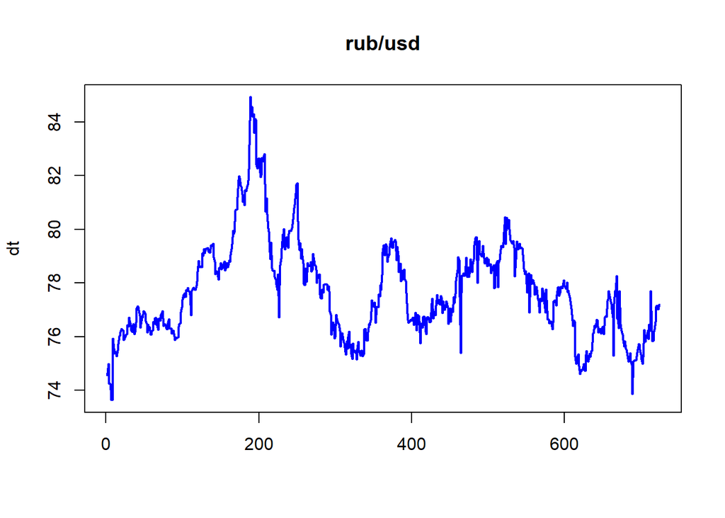

```r
Data <- read.csv("brent.csv",sep=",")
dt<-  Data[,2]
matplot(dt,type="l",col = "blue",main = "rub/usd",lwd=2)
```

Ряд не стационарен, перейдем к разностям

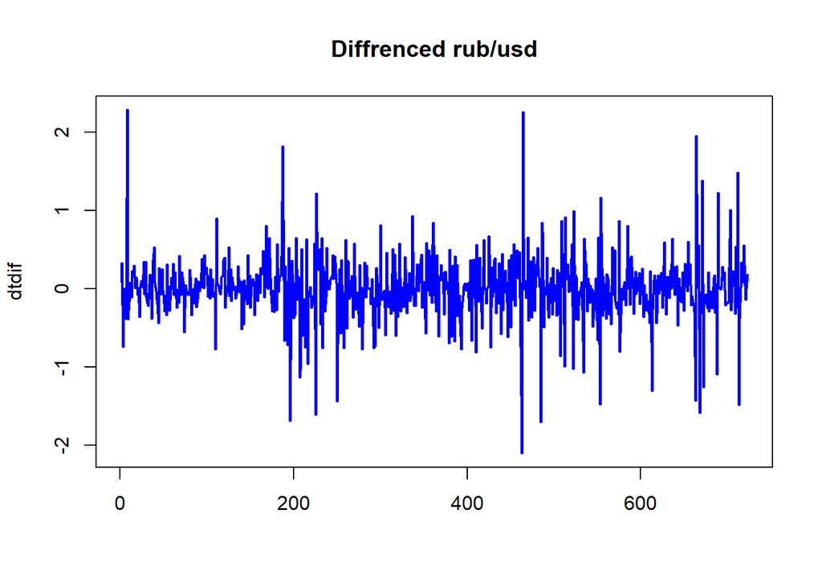

```r
dtdif <- diff(dt)

matplot(dtdif,type="l",col = "blue",main = "Diffrenced rub/usd",lwd=2)
```

Посмотрим ACF и PACF

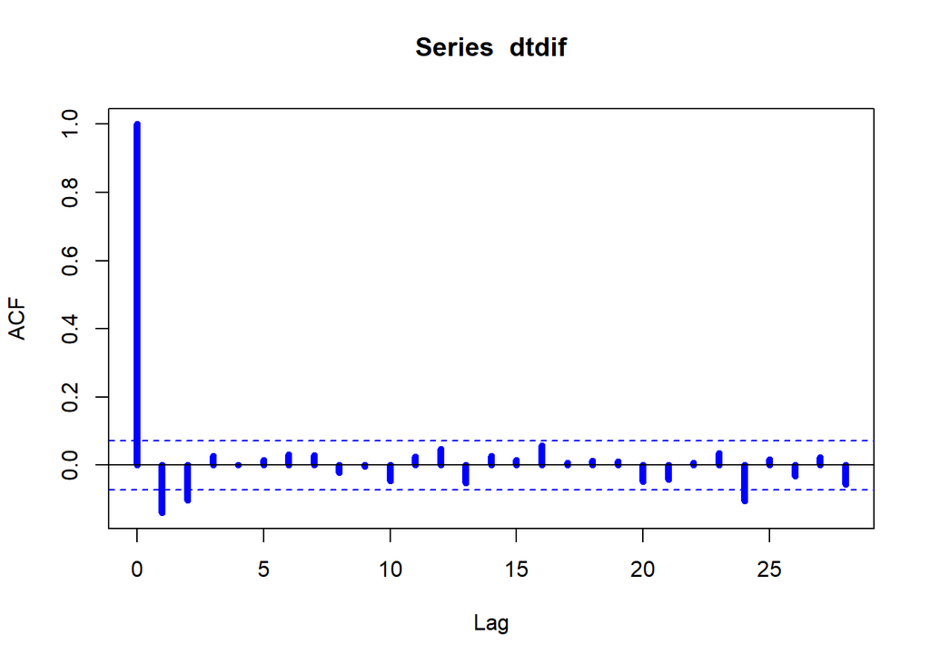

```r
acf(dtdif,col="blue",lwd  =5)
```

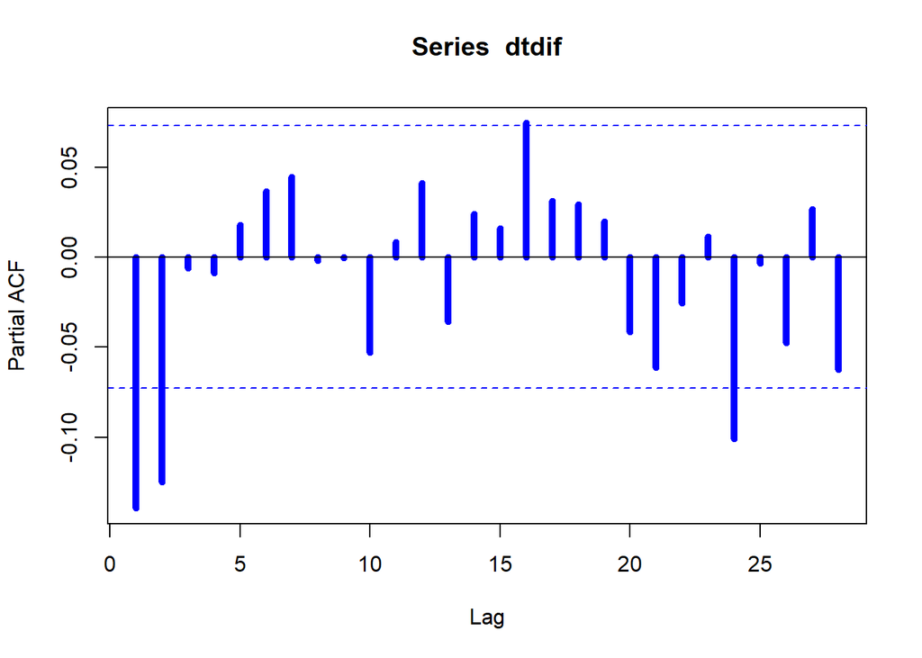

```r
pacf(dtdif,col="blue",lwd  =5)
```

PACF идентифицирует модель как AR(2) подгоним ее и представим в виде уравнений состояния и наблюдений фильтра Калмана Уравнение состояний
$$\xi_{t+1} = F\xi_t+u_t$$
уравнение наблюдений
$$y_t=H\xi_t+v_t$$

```r
fit2 <- arima(dtdif, c(2, 0, 0))
```

Матрица переходоа$F$

```r
fit2$model$T
```

```
##            [,1] [,2]
## [1,] -0.1566701    1
## [2,] -0.1245452    0
```

Матрица $H$

```r
fit2$model$Z
```

```
## [1] 1 0
```

Текущее состояние $\tilde\xi_{T-1:T}$

```r
fit2$model$a
```

```
## [1]  1.794680e-01 -5.828181e-05
```

Сглаживание при помощи фильтра Калмана

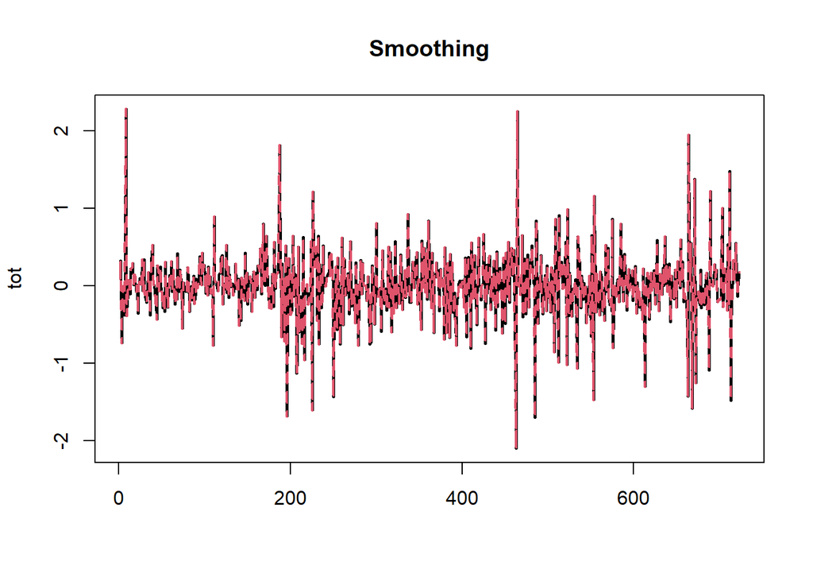

```r
klike<- KalmanSmooth(dtdif,mod=fit2$model)
tot<-cbind(klike$smooth[,1],dtdif)
matplot(tot,type ="l",lwd=2,main = "Smoothing")
```

Прогнозирование $y_t$ на $l=10$ шагов вперед

```r
forec <- KalmanForecast(n.ahead = 10L, mod=fit2$model, update = FALSE)
forec
```

```
## $pred
##  [1] -2.817554e-02 -1.793761e-02  6.319414e-03  1.243980e-03 -9.819472e-04
##  [6] -1.090053e-06  1.224676e-04 -1.905124e-05 -1.226799e-05  4.294768e-06
##
## $var
##  [1] 1.000000 1.024546 1.034545 1.035783 1.035831 1.035861 1.035861 1.035862
##  [9] 1.035862 1.035862
```

## Оценка параметров

При предположении о распределении $v_t,w_t$ как многомерном нормальном с нулевым математическим ожиданием и ковариационными матрицами $Q,R$ соответственно условное распределение $y_t$ при условии, что известно $x_,Y_{t-1}= (x_1,x_2,...x_{t-1};y_1,y_2,...,y_{t-1}$ будет нормальным

$$y_t|x_t,Y_{t-1}\sim N(A'x_t+H'\xi_{t|t-1},(H'P_{t|t-1}H+R))$$
поэтому
$$f(y_t|x_t,Y_{t-1})=(2\pi)^{n/2}|H'P_{t|t-1}H|^{-1/2}*exp(-1/2(y_t-A'x_t-H'\xi_{t|t-1})'(H'P_{t|t-1}H+R)^{-1}(y_t-A'x_t-H'\xi_{t|t-1}); t = 1,2,...T$$
Отсюда приходим к логарифму функции правдоподобия
$$\sum_{t=1}^Tln(f(y_t|x_t,Y_{t-1})$$
, которое максимизируется численно относительно параметров модели $F,Q,A,H,R$

Фильтр Калмана пытается оценить состояние системы в текущий момент времени, основываясь на своей оценке в предыдущий момент времени, а также на новых результатах измерений.

# Литература

- Brockwell, P. J. and Davis, R. A. (1996) Introduction to Time Series and Forecasting. Springer, New York. Sections 3.3 and 8.3.
- Hamilton J.D. (1994): Time Series Analysis. Princeton University Press.
- Durbin, J. and Koopman, S. J. (2001) Time Series Analysis by State Space Methods. Oxford University Press.
- Gardner, G, Harvey, A. C. and Phillips, G. D. A. (1980) Algorithm AS154. An algorithm for exact maximum likelihood estimation of autoregressive-moving average models by means of Kalman filtering. Applied Statistics 29, 311–322.